# DATA 612 Final Project

# 1 Project Goal

The goal for the final project is to build out a recommender system using a large dataset (e.g. 1M+ ratings or 10k+ users, 10k+ items). If you would like to use one of the datasets you have already worked with, you should add a uniqle element or incorporate additional data. The overall goal, however, will be to produce quality recommendations by extracting insights fom a large dataset. You may do so using Spark, or another distributed computing method, OR by effectively applying one of the more advanced mathematical techniques we have covered. There is no preference for one over the other, as long as your recommender works! Make a five-minute presentation of your system in our final meetup on Thursday.

# 2 Introduction

In this project, we are going to build out a recommender system using different algorithms for movie recommendations by using `MovieLens` datasets, which can be found at [https://grouplens.org/datasets/movielens/latest/] or [http://grouplens.org/datasets/]. This `MovieLens` dataset is different from the `MovieLense` dataset we used in project 4. We will implement User-Based Collaborative Filtering (UBCF) model, Item-Based Collaborative Filtering (IBCF) model, singular value decomposition (SVD) model, alternating least square (ALS) model, and Spark ALS model to our datasets and compare their performance.

## 2.1 Note

To develop an efficient program of this project in PC environment but yet to effectively demonstrate building recommender systems using R studio, we will be covering two MovieLens datasets. A relatively smaller MovieLens dataset of 100k+ observations will be used when building recommender systems using the package `Recommenderlab` in the first section. However to meet the size requirement of data in this project, a larger MovieLens dataset with 27M+ ratings that is shrinked to around 12,000 users and 12,000 movies will be used when building a recommender system using `sparklyr` in the second section.

# 3 Load Library

```r
library(tidyverse)
library(sparklyr)
library(recommenderlab)
library(knitr)
library(kableExtra)
library(scales)
library(gplots)
library(shiny)
set.seed(0)
```

# 4 Build Model in RecommenderLab

## 4.1 Import Small MovieLens Dataset

### 4.1.1 Read data from CSV

```r
movie <- read.csv("https://raw.githubusercontent.com/oggyluky11/DATA-612-2020-SUMMER/master/Final%20Project/movies.csv")
ratings <- read.csv("https://raw.githubusercontent.com/oggyluky11/DATA-612-2020-SUMMER/master/Final%20Project/ratings.csv")
```

## 4.2 Data Exploration

The `MovieLens` dataset we are going to use for the this section contains 100,836 ratings and 3,683 tag applications across 9,742 movies. These data were created by 610 users between March 29, 1996 and September 24, 2018, and generated as a dataset on September 26, 2018. All users had rated at least 20 movies. Each user is represented by an ID and no other information is provided. All ratings are made on a 5-star scale with half-star increments (0.5 star - 5.0 stars). From the explorations below, this dataset is quite sparse.

### 4.2.1 Data: Ratings

Here is a glimpse of the `ratings` dataset.

We can take a look at the `ratings` dataset in both long format and wide format below.

```r
head(ratings, 5)
```

|  | userId | movieId | rating | timestamp |
| --- | --- | --- | --- | --- |
| 1 | 1 | 1 | 4 | 964982703 |
| 2 | 1 | 3 | 4 | 964981247 |
| 3 | 1 | 6 | 4 | 964982224 |
| 4 | 1 | 47 | 5 | 964983815 |
| 5 | 1 | 50 | 5 | 964982931 |

```r
glimpse(ratings)
```

```
## Observations: 100,836
## Variables: 4
## $ userId    <int> 1, 1, 1, 1, 1, 1, 1, 1, 1, 1, 1, 1, 1, 1, 1, 1, 1, 1...
## $ movieId   <int> 1, 3, 6, 47, 50, 70, 101, 110, 151, 157, 163, 216, 2...
## $ rating    <dbl> 4, 4, 4, 5, 5, 3, 5, 4, 5, 5, 5, 5, 3, 5, 4, 5, 3, 3...
## $ timestamp <int> 964982703, 964981247, 964982224, 964983815, 96498293...
```

```r
ratings %>%
  select(userId, movieId, rating) %>%
  spread(key = movieId, value = rating) %>%
  head(10)
```

|  | userId | 1 | 2 | 3 | 4 | 5 | 6 | 7 | 8 | 9 | 10 | 11 | 12 | 13 | 14 | 15 | 16 | 17 | 18 | 19 | 20 | 21 | 22 | 23 | 24 | 25 | 26 | 27 | 28 | … |
| --- | --- | --- | --- | --- | --- | --- | --- | --- | --- | --- | --- | --- | --- | --- | --- | --- | --- | --- | --- | --- | --- | --- | --- | --- | --- | --- | --- | --- | --- | --- |
| 1 | 1 | 4.0 | NA | 4 | NA | NA | 4 | NA | NA | NA | NA | NA | NA | NA | NA | NA | NA | NA | NA | NA | NA | NA | NA | NA | NA | NA | NA | NA | NA | … |
| 2 | 2 | NA | NA | NA | NA | NA | NA | NA | NA | NA | NA | NA | NA | NA | NA | NA | NA | NA | NA | NA | NA | NA | NA | NA | NA | NA | NA | NA | NA | … |
| 3 | 3 | NA | NA | NA | NA | NA | NA | NA | NA | NA | NA | NA | NA | NA | NA | NA | NA | NA | NA | NA | NA | NA | NA | NA | NA | NA | NA | NA | NA | … |
| 4 | 4 | NA | NA | NA | NA | NA | NA | NA | NA | NA | NA | NA | NA | NA | NA | NA | NA | NA | NA | NA | NA | 3 | NA | NA | NA | NA | NA | NA | NA | … |
| 5 | 5 | 4.0 | NA | NA | NA | NA | NA | NA | NA | NA | NA | NA | NA | NA | NA | NA | NA | NA | NA | NA | NA | 4 | NA | NA | NA | NA | NA | NA | NA | … |
| 6 | 6 | NA | 4 | 5 | 3 | 5 | 4 | 4 | 3 | NA | 3 | 4 | NA | 3 | NA | 4 | 4 | 4 | NA | 2 | NA | 2 | 5 | NA | 4 | 3 | 4 | 3 | NA | … |
| 7 | 7 | 4.5 | NA | NA | NA | NA | NA | NA | NA | NA | NA | NA | NA | NA | NA | NA | NA | NA | NA | NA | NA | NA | NA | NA | NA | NA | NA | NA | NA | … |
| 8 | 8 | NA | 4 | NA | NA | NA | NA | NA | NA | NA | 2 | 4 | NA | NA | NA | NA | NA | NA | NA | NA | NA | 4 | NA | NA | NA | NA | NA | NA | NA | … |
| 9 | 9 | NA | NA | NA | NA | NA | NA | NA | NA | NA | NA | NA | NA | NA | NA | NA | NA | NA | NA | NA | NA | NA | NA | NA | NA | NA | NA | NA | NA | … |
| 10 | 10 | NA | NA | NA | NA | NA | NA | NA | NA | NA | NA | NA | NA | NA | NA | NA | NA | NA | NA | NA | NA | NA | NA | NA | NA | NA | NA | NA | NA | … |

The dataset is very sparse as observed from the heapmap of a subset of the dataset shown below.

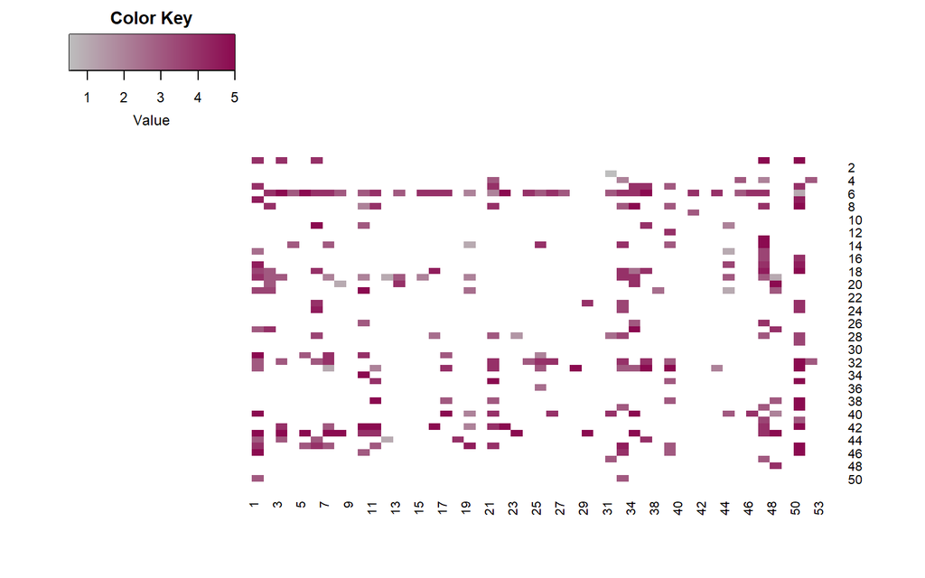

heatmap of partial dataset

```r
ratings %>%
  select(userId, movieId, rating) %>%
  spread(key = movieId, value = rating) %>%
  filter(userId %in% c(1:50)) %>%
  select(c(1:50)) %>%
  column_to_rownames('userId') %>%
  as.matrix() %>%
  heatmap.2(trace = 'none',
            dendrogram = 'none',
            density.info = 'none',
            Rowv = FALSE,
            Colv = FALSE,
            col = colorRampPalette(c('grey','deeppink4'))(n=299))
```

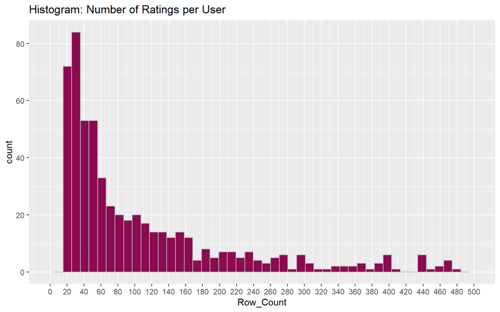

```r
ratingmat <- ratings %>%
  select(userId, movieId, rating) %>%
  spread(key = movieId, value = rating) %>%
  select(-userId) %>%
  as.matrix() %>%
  as('realRatingMatrix')

ratingmat %>%
  rowCounts() %>%
  data.frame(Row_Count = .) %>%
  ggplot(aes(x=Row_Count)) +
  geom_histogram(fill = 'deeppink4', color = 'grey', bins = 50) +
  #geom_text(stat= 'count', vjust=-0.5)+
  scale_x_continuous(limits = c(0,500),breaks = seq(0,500,20)) +
  labs(title = 'Histogram: Number of Ratings per User')
```

Most movies are rated by no more than 5 users.

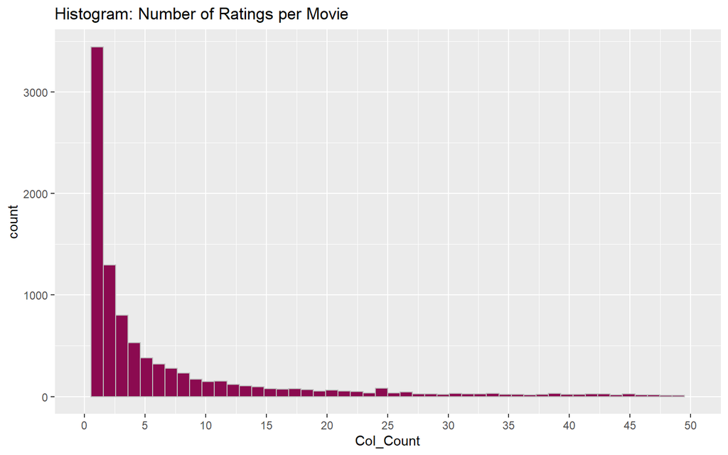

```r
ratingmat %>%
  colCounts() %>%
  data.frame(Col_Count = .) %>%
  ggplot(aes(x=Col_Count)) +
  geom_histogram(fill = 'deeppink4', color = 'grey', bins = 50) +
  #geom_text(stat= 'count', vjust=-0.5)+
  scale_x_continuous(limits = c(0,50),breaks = seq(0,50,5)) +
  labs(title = "Histogram: Number of Ratings per Movie")
```

```r
#remove local variables, clear space for the downstream process
#rm(movies, ratings)
```

### 4.2.2 Data: Movie

Here is a glimpse of the `movie` dataset.

It contains movie IDs, movie names and genres.

```r
head(movie)
```

|  | movieId | title | genres |
| --- | --- | --- | --- |
| 1 | 1 | Toy Story (1995) | Adventure\|Animation\|Children\|Comedy\|Fantasy |
| 2 | 2 | Jumanji (1995) | Adventure\|Children\|Fantasy |
| 3 | 3 | Grumpier Old Men (1995) | Comedy\|Romance |
| 4 | 4 | Waiting to Exhale (1995) | Comedy\|Drama\|Romance |
| 5 | 5 | Father of the Bride Part II (1995) | Comedy |
| 6 | 6 | Heat (1995) | Action\|Crime\|Thriller |

```r
glimpse(movie)
```

```
## Observations: 9,742
## Variables: 3
## $ movieId <int> 1, 2, 3, 4, 5, 6, 7, 8, 9, 10, 11, 12, 13, 14, 15, 16,...
## $ title   <fct> "Toy Story (1995)", "Jumanji (1995)", "Grumpier Old Me...
## $ genres  <fct> Adventure|Animation|Children|Comedy|Fantasy, Adventure...
```

### 4.2.3 User Similarity

We can see the similarity between users by looking at the heatmap. White color represents no data.

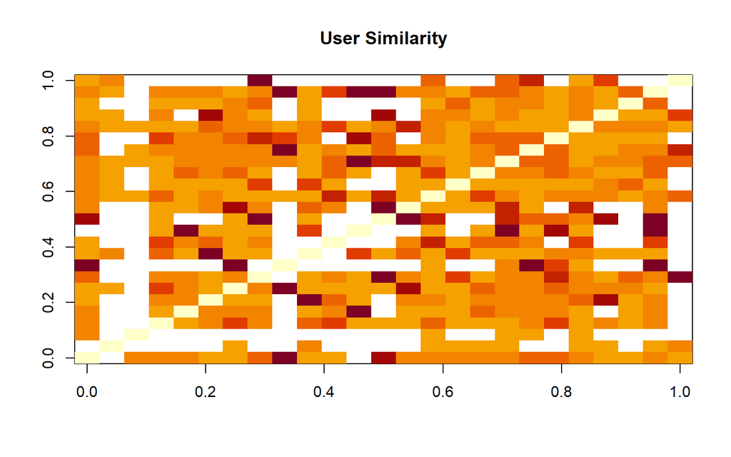

```r
similarity_users <- similarity(ratingmat[1:25, ],
                               method = "pearson",
                               which = "users")

image(as.matrix(similarity_users), main = "User Similarity")
```

### 4.2.4 Item Similarity

We can see the similarity between items by looking at the heatmap. White color represents no data.

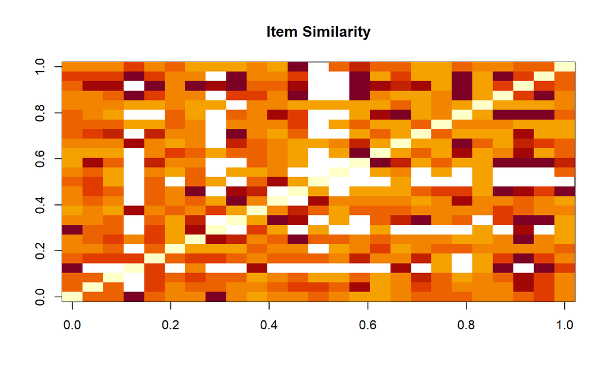

```r
similarity_items <- similarity(ratingmat[, 1:25], method =
                                 "pearson", which = "items")
image(as.matrix(similarity_items), main = "Item Similarity")
```

## 4.3 Select Sample Data

Select data that has rowcount > 50 and colcount > 100 as our sample dataset.

```r
ratings_movies <- ratingmat[rowCounts(ratingmat) > 50,
                             colCounts(ratingmat) > 100]
```

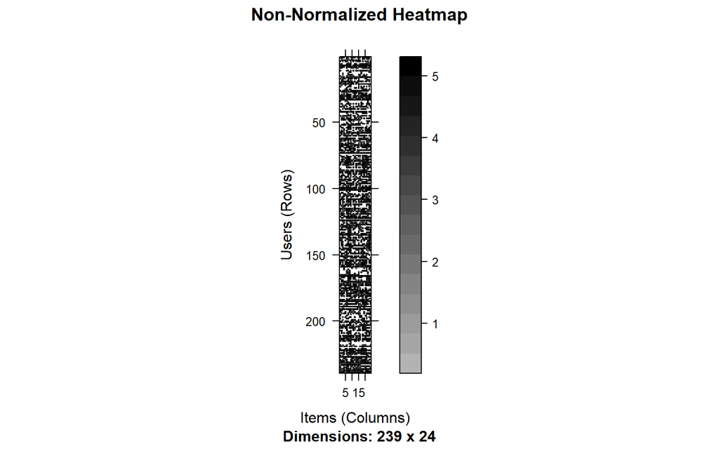

```r
min_movies <- quantile(rowCounts(ratings_movies), 0.95)
min_users <- quantile(colCounts(ratings_movies), 0.95)

image(ratingmat[rowCounts(ratingmat) > min_movies,
colCounts(ratingmat) > min_users], main = "Non-Normalized Heatmap")
```

This is a normalized heatmap of our sample dataset at quantile 0.95.

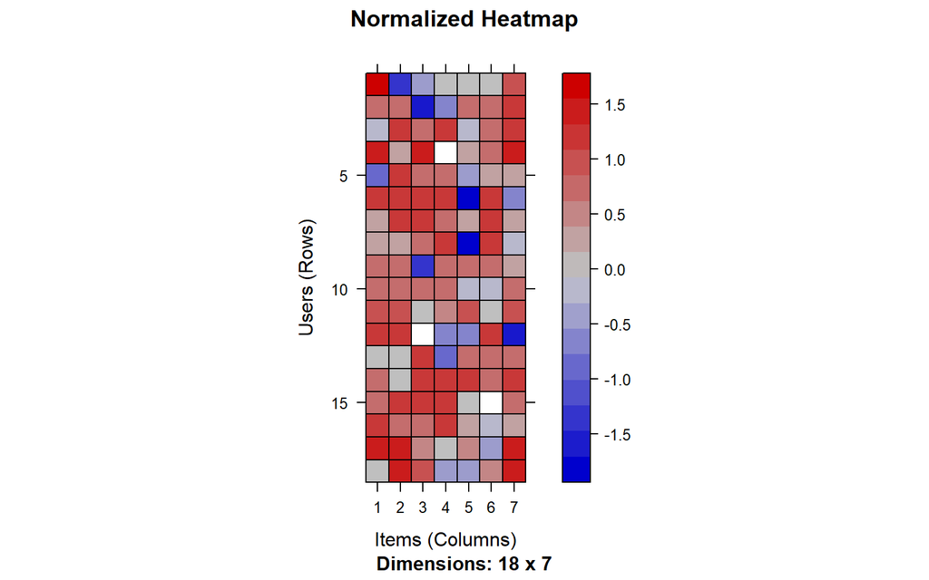

```r
rating_movie_normalize <- normalize(ratings_movies)

min_movies <- quantile(rowCounts(rating_movie_normalize), 0.95)
min_users <- quantile(colCounts(rating_movie_normalize), 0.95)

image(rating_movie_normalize[rowCounts(rating_movie_normalize) > min_movies,
colCounts(rating_movie_normalize) > min_users], main = "Normalized Heatmap")
```

## 4.4 Build Models

We are going to build models using the library `RecommenderLab` with different algorithms. We will implement User-Based Collaborative Filtering (UBCF) model, Item-Based Collaborative Filtering (IBCF) model, singular value decomposition (SVD) model and alternating least square (ALS) model, and compare their performance.

### 4.4.1 Train-Test Split

```r
eval_sets <- evaluationScheme(data = ratings_movies, method = "split", train = 0.8, given = 4, goodRating = 3, k = 1)
```

### 4.4.2 UBCF Models

We will evaluate three models of User-Based Collaborative Filtering (UBCF) algorithm by using the `recommenderlab` package with mean-centering normalization technique and three similarity measures (Pearson correlation, Euclidean distance and Cosine distance).

```r
ubcf_models <- list(
  ubcf_prs_center = list(name = "UBCF", param = list(method = "pearson", normalize = "center")),
  ubcf_euc_center = list(name = "UBCF", param = list(method = "euclidean", normalize = "center")),
  ubcf_cos_center = list(name = "UBCF", param = list(method = "cosine", normalize = "center"))
)

ubcf_eval_results <- evaluate(eval_sets,
                              method = ubcf_models,
                              n = seq(10, 100, 10)
                              )
```

```
## UBCF run fold/sample [model time/prediction time]
##   1  [0.02sec/0.05sec]
## UBCF run fold/sample [model time/prediction time]
##   1  [0sec/0.06sec]
## UBCF run fold/sample [model time/prediction time]
##   1  [0sec/0.03sec]
```

The results of the three UBCF models are plotted below in ROC curve and Precision-Recall.

UBCF model with Pearson correlation performs the best among the three models.

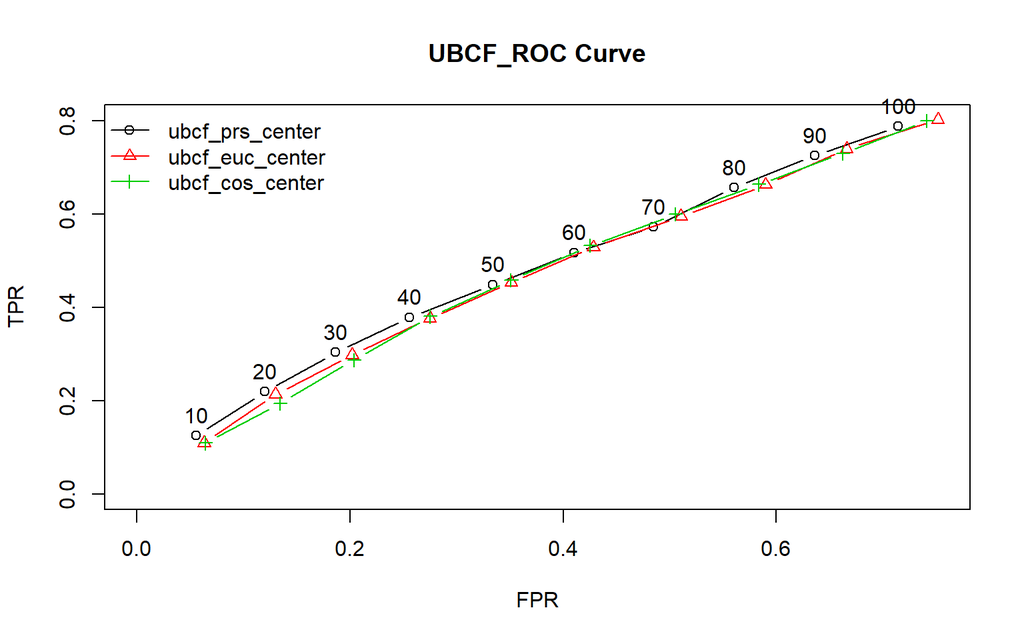

```r
plot(ubcf_eval_results, annotate = TRUE, legend="topleft")
title("UBCF_ROC Curve")
```

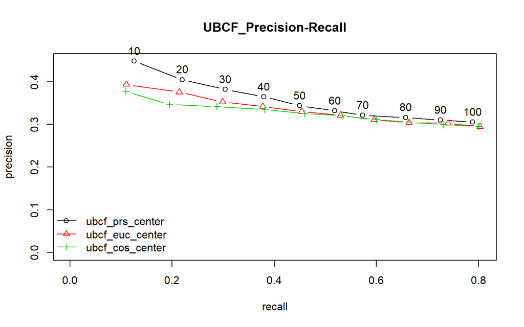

```r
plot(ubcf_eval_results, "prec/rec", annotate = TRUE, legend="bottomleft")
title("UBCF_Precision-Recall")
```

### 4.4.3 IBCF Models

```r
ibcf_models <- list(
  ibcf_prs_center = list(name = "IBCF", param = list(method = "pearson", normalize = "center")),
  ibcf_euc_center = list(name = "IBCF", param = list(method = "euclidean", normalize = "center")),
  ibcf_cos_center = list(name = "IBCF", param = list(method = "cosine", normalize = "center")),
  ibcf_cos_NULL = list(name = "IBCF", param = list(method = "cosine", normalize = NULL))
)
ibcf_eval_results <- evaluate(eval_sets,
                              method = ibcf_models,
                              n = seq(10, 100, 10)
                              )
```

```
## IBCF run fold/sample [model time/prediction time]
##   1  [0.04sec/0.01sec]
## IBCF run fold/sample [model time/prediction time]
##   1  [0.03sec/0.01sec]
## IBCF run fold/sample [model time/prediction time]
##   1  [0.03sec/0.02sec]
## IBCF run fold/sample [model time/prediction time]
##   1  [0.03sec/0sec]
```

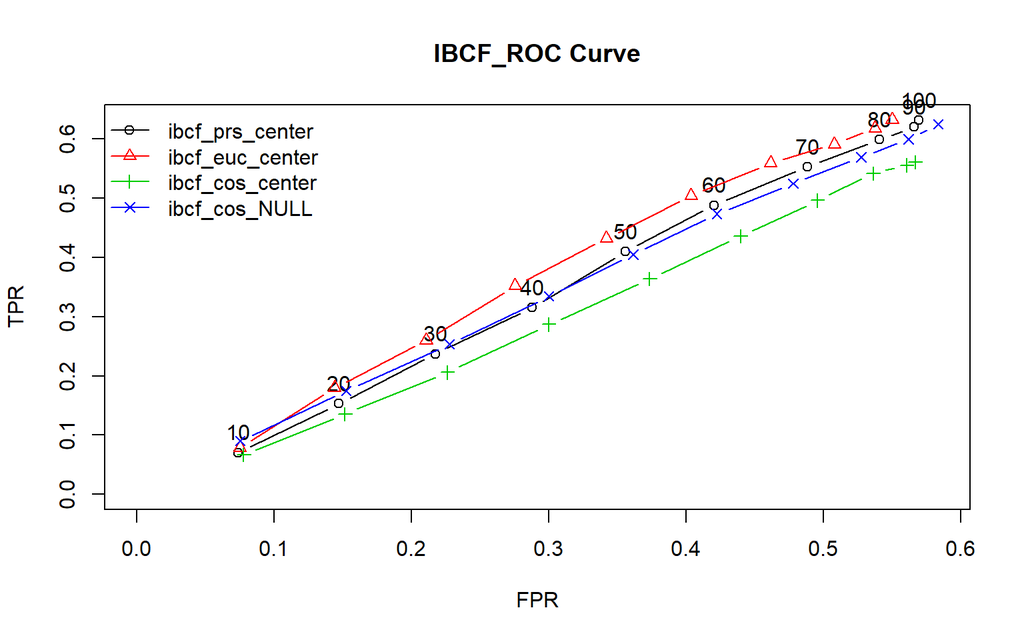

```r
plot(ibcf_eval_results, annotate = TRUE, legend="topleft")
title("IBCF_ROC Curve")
```

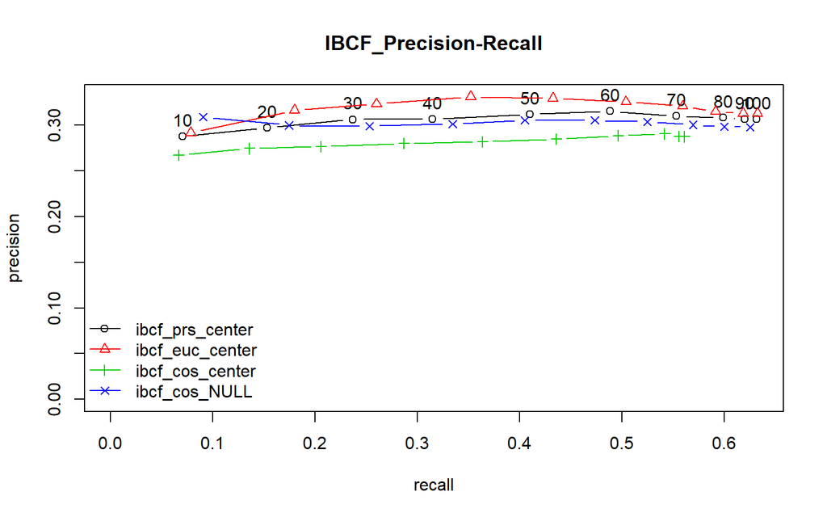

```r
plot(ibcf_eval_results, "prec/rec", annotate = TRUE, legend="bottomleft")
title("IBCF_Precision-Recall")
```

### 4.4.4 SVD Models

We will evaluate three models of Singular Value Decomposition (SVD) algorithm by using the `recommenderlab` package with non-normalization, mean-centering normalization, z-score normalization technique.

```r
svd_models <- list(
  svd_center = list(name = "SVD", param = list(normalize = "center")),
  svd_z = list(name = "SVD", param = list(normalize = "Z-score")),
  svd = list(name = 'SVD', param = list(normalize = NULL))
)
svd_eval_results <- evaluate(x = eval_sets,
                                 method = svd_models,
                                 n = seq(10, 100, 10))
```

```
## SVD run fold/sample [model time/prediction time]
##   1  [0sec/0.02sec]
## SVD run fold/sample [model time/prediction time]
##   1  [0.01sec/0.02sec]
## SVD run fold/sample [model time/prediction time]
##   1  [0.01sec/0sec]
```

The results of the three SVD models are plotted below in ROC curve and Precision-Recall.

SVD model without normalization performs the best among the three models.

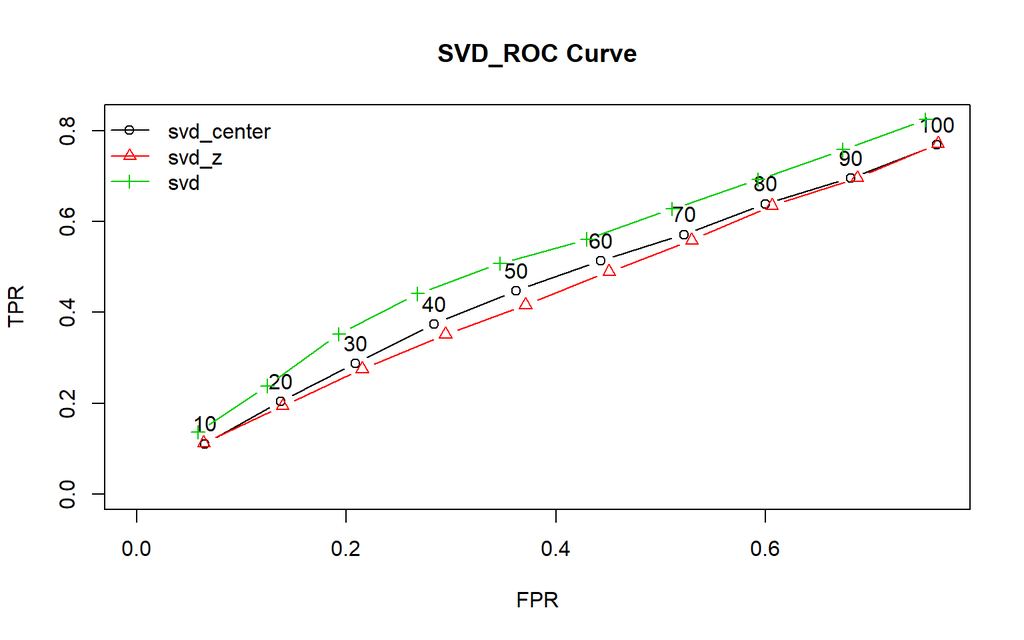

```r
plot(svd_eval_results, annotate = TRUE, legend="topleft")
title("SVD_ROC Curve")
```

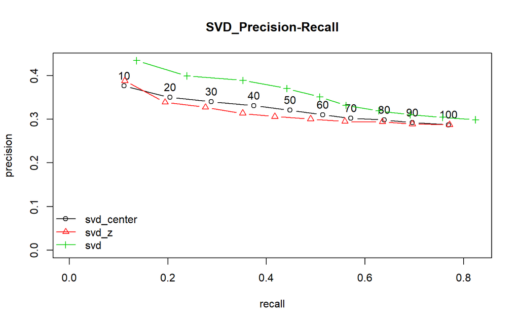

```r
plot(svd_eval_results, "prec/rec", annotate = TRUE, legend="bottomleft")
title("SVD_Precision-Recall")
```

### 4.4.5 ALS Models

We will evaluate three models of alternating least square (ALS) algorithm by using the `recommenderlab` package with non-normalization, mean-centering normalization, z-score normalization technique.

```r
als_models <- list(
  als_center = list(name = "ALS", param = list(normalize = "center")),
  als_z = list(name = "ALS", param = list(normalize = "Z-score")),
  als = list(name = 'ALS', param = list(normalize = NULL))
)
als_eval_results <- evaluate(x = eval_sets,
                                 method = als_models,
                                 n = seq(10, 100, 10))
```

```
## ALS run fold/sample [model time/prediction time]
##   1  [0sec/2.39sec]
## ALS run fold/sample [model time/prediction time]
##   1  [0sec/2.42sec]
## ALS run fold/sample [model time/prediction time]
##   1  [0sec/2.37sec]
```

The results of the three ALS models are plotted below in ROC curve and Precision-Recall.

ALS model without normalization performs the best among the three models.

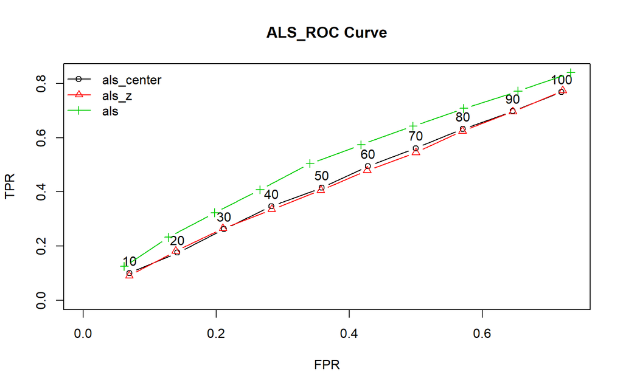

```r
plot(als_eval_results, annotate = TRUE, legend="topleft")
title("ALS_ROC Curve")
```

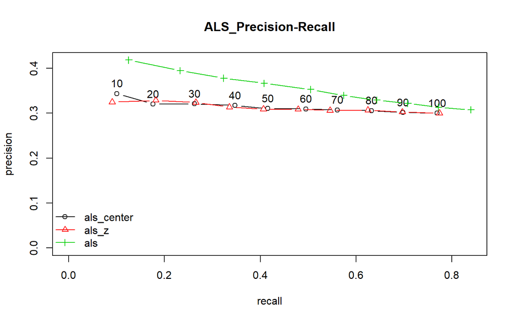

```r
plot(als_eval_results, "prec/rec", annotate = TRUE, legend="bottomleft")
title("ALS_Precision-Recall")
```